# 時系列分析 第2回 分析例

Kenichiro Tamaki

2022年4月18日

# 1 パッケージ quantmod

本パッケージを用いると, Yahoo Finance (US) から株価などのファイナンスデータを容易に入手できる. さらに, ソースを変更することにより, GDPなどのマクロデータも入手できる.

```r
install.packages("quantmod") # パッケージをインストール
```

```r
library("quantmod") # パッケージを読み込む
```

# 2 株価の分析例

## 2.1 データの入手と編集

株価データは Yahoo Finance (US) から入手可能である.

- https://finance.yahoo.com

まず, 上記からデータの Symbols を調べる. 企業名や証券コードで検索すれば良いが, 取引所により Symbols が異なる.

- Apple
  - AAPL (NMS: ナスダック証券取引所)  
    https://finance.yahoo.com/quote/AAPL
  - APC.F (FRA: フランクフルト証券取引所)  
    https://finance.yahoo.com/quote/APC.F
- トヨタ自動車 (Toyota Motor Corporation)
  - 7203.T (JPX: 東京証券取引所, 7203は証券コード)  
    https://finance.yahoo.com/quote/7203.T
  - TM (NYQ: ニューヨーク証券取引所)  
    https://finance.yahoo.com/quote/TM

ここでは, Appleの日次株価を入手する.

```r
getSymbols("AAPL") # データを取得し AAPL に代入
```

```
## [1] "AAPL"
```

```r
head(AAPL, 5) # 最初の5個を表示
```

```
##            AAPL.Open AAPL.High AAPL.Low AAPL.Close AAPL.Volume AAPL.Adjusted
## 2007-01-03  3.081786  3.092143 2.925000   2.992857  1238319600      2.562706
## 2007-01-04  3.001786  3.069643 2.993571   3.059286   847260400      2.619587
## 2007-01-05  3.063214  3.078571 3.014286   3.037500   834741600      2.600933
## 2007-01-08  3.070000  3.090357 3.045714   3.052500   797106800      2.613777
## 2007-01-09  3.087500  3.320714 3.041071   3.306071  3349298400      2.830903
```

```r
tail(AAPL, 5) # 最後の5個を表示
```

```
##            AAPL.Open AAPL.High AAPL.Low AAPL.Close AAPL.Volume AAPL.Adjusted
## 2022-04-07    171.16    173.36   169.85     172.14    77594700        172.14
## 2022-04-08    171.78    171.78   169.20     170.09    76515900        170.09
## 2022-04-11    168.71    169.03   165.50     165.75    72246700        165.75
## 2022-04-12    168.02    169.87   166.64     167.66    79265200        167.66
## 2022-04-13    167.39    171.04   166.77     170.40    70551700        170.40
```

- Open = 始値, High = 高値, Low = 安値, Close = 終値, Volume = 出来高, Adjusted = 調整後終値
- 終値: 株式分割を調整  
  Close price adjusted for splits.
- 調整後終値: 株式分割と配当を調整  
  Adjusted close price adjusted for splits and dividend and/or capital gain distributions.
- 調整方法の詳細は次のHelpをご覧下さい  
  https://help.yahoo.com/kb/adjusted-close-sln28256.html

ここでは, 終値を用いる.

```r
aapl <- AAPL$AAPL.Close # 終値
```

記述統計量は次である.

```r
library(stargazer) # パッケージを読み込む
stargazer(aapl, # 標本
          type = "text", # 出力形式
          summary = TRUE) # 記述統計量
```

```
##
## ==============================================
## Statistic    N    Mean  St. Dev.  Min    Max
## ----------------------------------------------
## AAPL.Close 3,848 37.626  41.067  2.793 182.010
## ----------------------------------------------
```

データの一部を取り出したい場合は次のようにすれば良い.

```r
aapl['2000'] # 2000年
aapl['2000-01'] # 2000年1月
aapl['2000-01-01::'] # 2000年1月1日以降
aapl['::2000-01-01'] # 2000年1月1日以前
aapl['2000-01-01::2020-12-31'] # 2000年1月1日から2020年12月31日まで
```

## 2.2 株価

Appleの株価の時系列とコレログラム (自己相関関数) をプロットする.

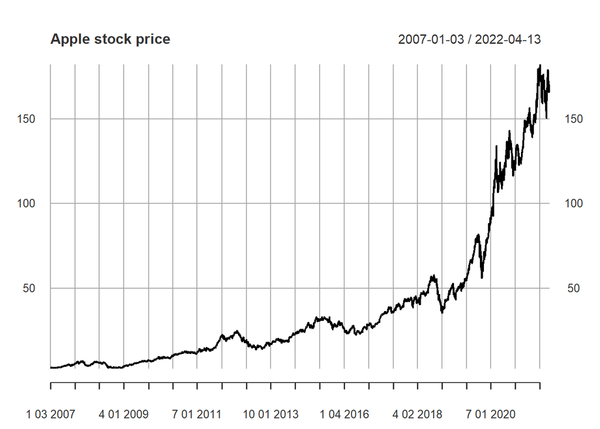

```r
# 時系列プロット
plot(aapl, # 標本
     main = "Apple stock price") # 図題
```

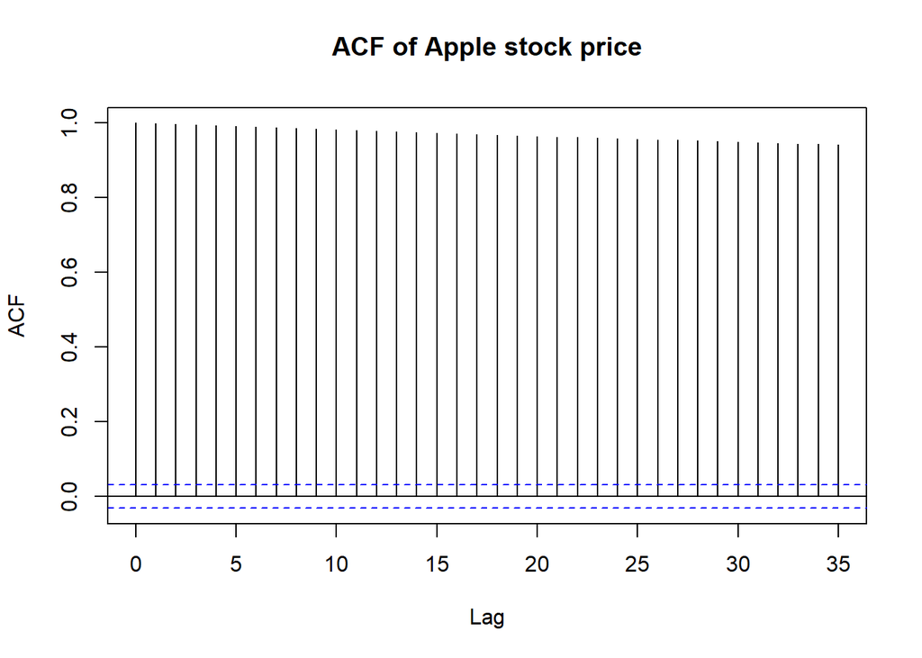

```r
# コレログラム
acf(coredata(aapl), # 標本, aapl ではエラーとなるので coredata(aapl) を用いる
    main = "ACF of Apple stock price") # 図題
```

コレログラムより, 全てのラグにおいて自己相関があると判断できる.

```r
(T <- length(aapl)) # 標本数
```

```
## [1] 3848
```

```r
(m <- round(log(T))) # ラグ m の目安
```

```
## [1] 8
```

これより, ラグ $8$ のかばん検定を行う.

```r
(res <- Box.test(coredata(aapl), # 標本
                 lag = m, # ラグ
                 type = "Ljung-Box")) # Ljung and Box (1978)
```

```
##
##  Box-Ljung test
##
## data:  coredata(aapl)
## X-squared = 30355, df = 8, p-value < 2.2e-16
```

検定統計量の値は $Q(8) = 3.04\times 10^{4}$, $p$値は $0$ である. ラグ $8$, $16$, $24$ に対するかばん検定の結果の表を作成する.

**関数の作成**

```r
port <- function(x, lag) { # x = 標本, lag = ラグ
  res <- Box.test(x, lag = lag, type = "Ljung-Box") # かばん検定
  # ラグ, 検定統計量の値, 自由度, p値
  return(c(lag, res$statistic, res$parameter, res$p.value))
}
```

**表の作成**

```r
lag <- m * (1:3) # ラグ m, 2m, 3m
res <- sapply(lag, port, x = coredata(aapl)) # x に対して各 lag の port を計算
res <- t(res) # 転置
# 表を作成
knitr::kable(res, # 計算結果
             digits = c(0, 2, 0, 4), # 少数点以下の最大表示桁数
             col.names = c("$m$", "$Q(m)$", "自由度", "$p$値"), # 列名
             caption = "Appleの株価に対するかばん検定", # 表題
             format.args = list(scientific = FALSE)) # 指数表記をしない
```

Appleの株価に対するかばん検定

| $m$ | $Q(m)$ | 自由度 | $p$値 |
| --- | --- | --- | --- |
| 8 | 30354.92 | 8 | 0 |
| 16 | 59881.54 | 16 | 0 |
| 24 | 88648.65 | 24 | 0 |

全てにおいて$p$値が $0.05$ より小さいので, 有意水準 $5 \%$ で帰無仮説を棄却できる. つまり, 自己相関があると判断できる.

## 2.3 株価の対数収益率

株価を対数収益率に変換する.

```r
aapl.dr <- periodReturn(aapl, # 標本
                        period='daily', # 日次
                        type = 'log') # 対数収益率
```

記述統計量は次である.

```r
stargazer(aapl.dr, # 標本
          type = "text", # 出力形式
          summary = TRUE) # 記述統計量
```

```
##
## ===============================================
## Statistic       N   Mean  St. Dev.  Min    Max
## -----------------------------------------------
## daily.returns 3,848 0.001  0.020   -0.197 0.130
## -----------------------------------------------
```

株価の対数収益率の時系列とコレログラム (自己相関関数) をプロットする.

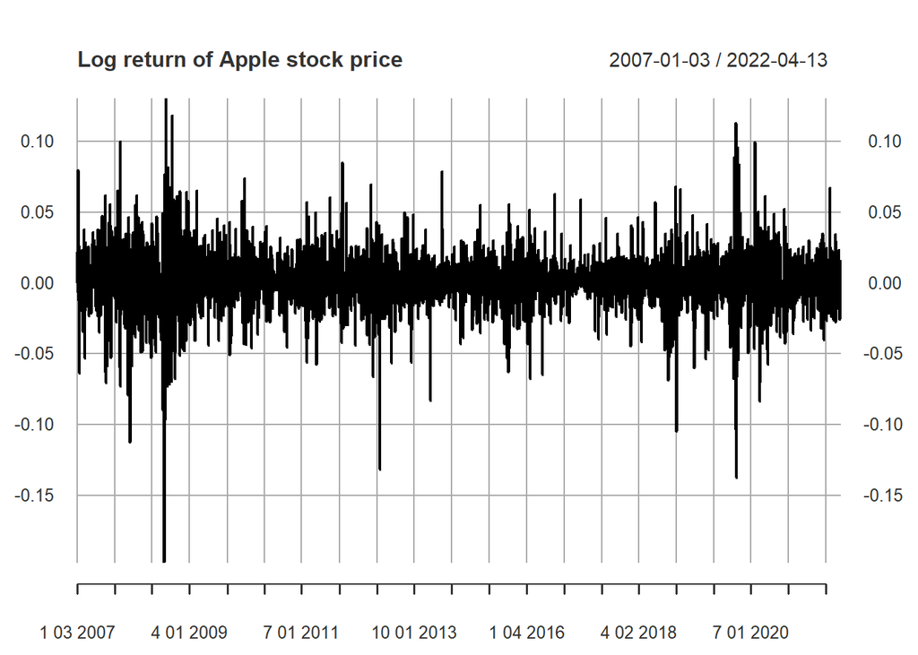

```r
# 時系列プロット
plot(aapl.dr, # 標本
     main = "Log return of Apple stock price") # 図題
```

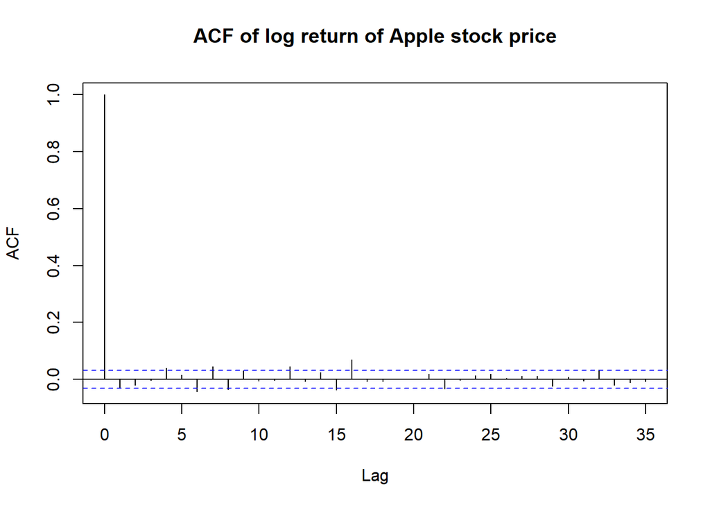

```r
# コレログラム
acf(aapl.dr, # 標本
    main = "ACF of log return of Apple stock price") # 図題
```

コレログラムより, 複数のラグにおいて自己相関があると判断できる.

```r
(T <- length(aapl.dr)) # 標本数
```

```
## [1] 3848
```

```r
(m <- round(log(T))) # ラグmの目安
```

```
## [1] 8
```

これより, ラグ $8$ のかばん検定を行う.

```r
(res <- Box.test(aapl.dr, # 標本
                 lag = m, # ラグ
                 type = "Ljung-Box")) # Ljung and Box (1978)
```

```
##
##  Box-Ljung test
##
## data:  aapl.dr
## X-squared = 31.046, df = 8, p-value = 0.0001379
```

検定統計量の値は $Q(8) = 31$, $p$値は $1.38\times 10^{-4}$ である. ラグ $8$, $16$, $24$ に対するかばん検定の結果の表を作成する.

```r
lag <- m * (1:3) # ラグ m, 2m, 3m
res <- sapply(lag, port, x = aapl.dr) # x に対して各 lag の port を計算
res <- t(res) # 転置
# 表を作成
knitr::kable(res, # 計算結果
             digits = c(0, 2, 0, 4), # 少数点以下の最大表示桁数
             col.names = c("$m$", "$Q(m)$", "自由度", "$p$値"), # 列名
             caption = "Appleの株価の対数収益率に対するかばん検定", # 表題
             format.args = list(scientific = FALSE)) # 指数表記をしない
```

Appleの株価の対数収益率に対するかばん検定

| $m$ | $Q(m)$ | 自由度 | $p$値 |
| --- | --- | --- | --- |
| 8 | 31.05 | 8 | 0.0001 |
| 16 | 68.38 | 16 | 0.0000 |
| 24 | 74.90 | 24 | 0.0000 |

全てにおいて$p$値が $0.05$ より小さいので, 有意水準 $5 \%$ で帰無仮説を棄却できる. つまり, 自己相関があると判断できる. よって, Appleの株価は, 原系列と対数収益率の両方において自己相関があると判断できる. コレログラムより, 原系列の自己相関は極めて強いが, 対数収益率の自己相関は弱いことが分かる.

# 3 GDPの分析例

## 3.1 データの入手と編集

マクロデータは FRED (Federal Reserve Economic Data) から入手可能である.

- https://fred.stlouisfed.org/

まず, 上記からデータの Symbols を調べる. 例えば, 日本のGDPは「gdp japan」と検索すれば良い. 四半期名目GDPは

- https://fred.stlouisfed.org/series/JPNNGDP

における, Gross Domestic Product for Japan (JPNNGDP) の括弧の中が Symbols である. ここでは, 日本の四半期名目GDP (単位: 10億円) を入手する.

```r
# Yahoo ではなく FRED からダウンロードするので src を変更する
getSymbols("JPNNGDP", src = "FRED") # データを取得し JPNNGDP に代入
```

```
## [1] "JPNNGDP"
```

```r
head(JPNNGDP, 5) # 最初の5個を表示
```

```
##             JPNNGDP
## 1994-01-01 510178.0
## 1994-04-01 509035.1
## 1994-07-01 512959.7
## 1994-10-01 511538.9
## 1995-01-01 514974.9
```

```r
tail(JPNNGDP, 5) # 最後の5個を表示
```

```
##             JPNNGDP
## 2020-10-01 546104.8
## 2021-01-01 543564.5
## 2021-04-01 544693.4
## 2021-07-01 538923.3
## 2021-10-01 540745.2
```

四半期データの場合は, 1994-01-01は1994年1月1日時点ではなく1994年第1四半期のデータである. 日付表示を変更したい場合は次のようにすれば良い.

```r
jpnngdp <- to.quarterly(JPNNGDP, OHLC = F) # 日付を四半期に変更
head(jpnngdp, 5) # 最初の5個を表示
```

```
##          JPNNGDP
## 1994 Q1 510178.0
## 1994 Q2 509035.1
## 1994 Q3 512959.7
## 1994 Q4 511538.9
## 1995 Q1 514974.9
```

記述統計量は次である.

```r
stargazer(jpnngdp, # 標本
          type = "text", # 出力形式
          summary = TRUE, # 記述統計量
          digits = 0) # 少数点以下の最大表示桁数
```

```
##
## ==============================================
## Statistic  N   Mean   St. Dev.   Min     Max
## ----------------------------------------------
## JPNNGDP   112 529,075  17,245  490,892 562,555
## ----------------------------------------------
```

データの一部を取り出したい場合は次のようにすれば良い.

```r
JPNNGDP['2000'] # 2000年
JPNNGDP['2000-01'] # 2000年第1四半期
JPNNGDP['2000-04'] # 2000年第2四半期
JPNNGDP['2000-01-01::'] # 2000年第1四半期以降
JPNNGDP['::2000-01-01'] # 2000年第1四半期以前
JPNNGDP['2000-01-01::2019-10-01'] # 2000年第1四半期から2019年第4四半期まで
# 日付情報を変更した場合も同じ
jpnngdp['2000-01-01::'] # 2000年第1四半期以降
```

## 3.2 GDP

GDPの時系列とコレログラム (自己相関関数) をプロットする.

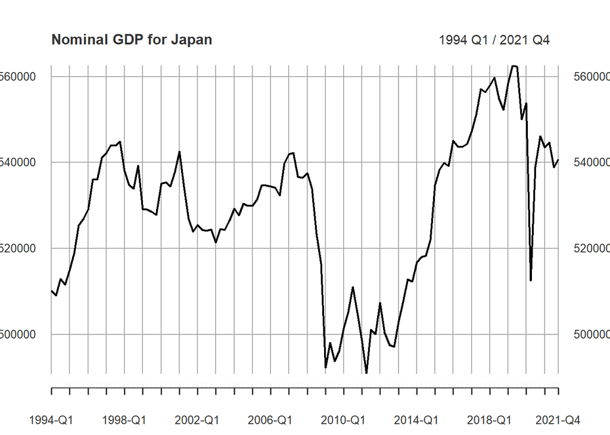

```r
# 時系列プロット
plot(jpnngdp, # 標本
     main = "Nominal GDP for Japan") # 図題
```

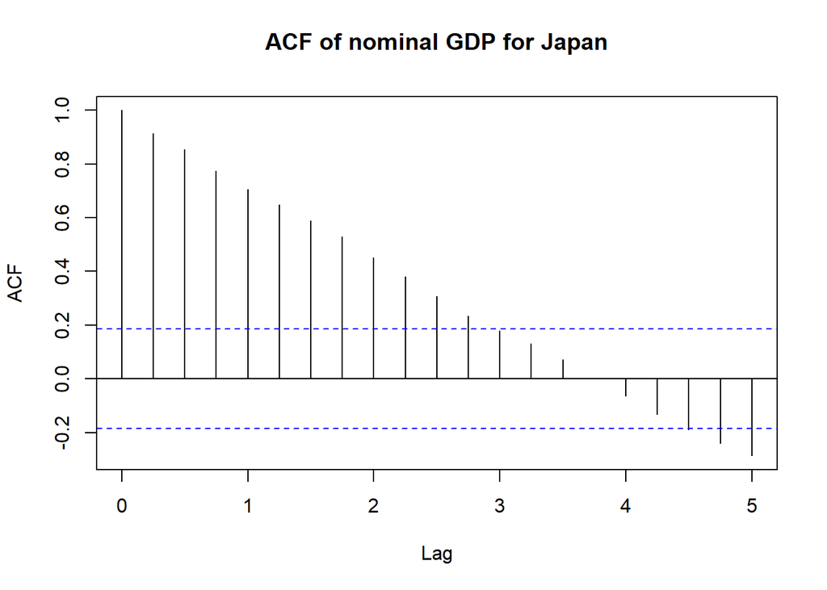

```r
# コレログラム
acf(jpnngdp, # 標本
    main = "ACF of nominal GDP for Japan") # 図題
```

四半期データの場合, コレログラムのラグ $1$ は $4$ を意味している. これより, 大部分のラグにおいて自己相関があると判断できる.

```r
(T <- length(jpnngdp)) # 標本数
```

```
## [1] 112
```

```r
(m <- round(log(T))) # ラグ m の目安
```

```
## [1] 5
```

これより, ラグ 5 のかばん検定を行う.

```r
(res <- Box.test(jpnngdp, # 標本
                 lag = m, # ラグ
                 type = "Ljung-Box")) # Ljung and Box (1978)
```

```
##
##  Box-Ljung test
##
## data:  jpnngdp
## X-squared = 360.31, df = 5, p-value < 2.2e-16
```

検定統計量の値は $Q(5) = 360$, $p$値は $0$ である. ラグ $5$, $10$, $15$ に対するかばん検定の結果の表を作成する.

```r
lag <- m * (1:3) # ラグ m, 2m, 3m
res <- sapply(lag, port, x = jpnngdp) # x に対して各 lag の port を計算
res <- t(res) # 転置
# 表を作成
knitr::kable(res, # 計算結果
             digits = c(0, 2, 0, 4), # 少数点以下の最大表示桁数
             col.names = c("$m$", "$Q(m)$", "自由度", "$p$値"), # 列名
             caption = "日本の名目GDPに対するかばん検定", # 表題
             format.args = list(scientific = FALSE)) # 指数表記をしない
```

日本の名目GDPに対するかばん検定

| $m$ | $Q(m)$ | 自由度 | $p$値 |
| --- | --- | --- | --- |
| 5 | 360.31 | 5 | 0 |
| 10 | 490.50 | 10 | 0 |
| 15 | 504.35 | 15 | 0 |

全てにおいて$p$値が $0.05$ より小さいので, 有意水準 $5 \%$ で帰無仮説を棄却できる. つまり, 自己相関があると判断できる.

## 3.3 GDP成長率

GDPを成長率 (%) に変換する.

```r
# 成長率に変換
jpnngdp.qr <- periodReturn(jpnngdp, # 標本
                           period='quarterly') # 四半期
jpnngdp.qr <- jpnngdp.qr * 100 # % に変換
```

記述統計量は次である.

```r
stargazer(jpnngdp.qr, # 標本
          type = "text", # 出力形式
          summary = TRUE) # 記述統計量
```

```
##
## =================================================
## Statistic          N  Mean  St. Dev.  Min    Max
## -------------------------------------------------
## quarterly.returns 112 0.060  1.279   -7.466 5.162
## -------------------------------------------------
```

GDP成長率の時系列とコレログラム (自己相関関数) をプロットする.

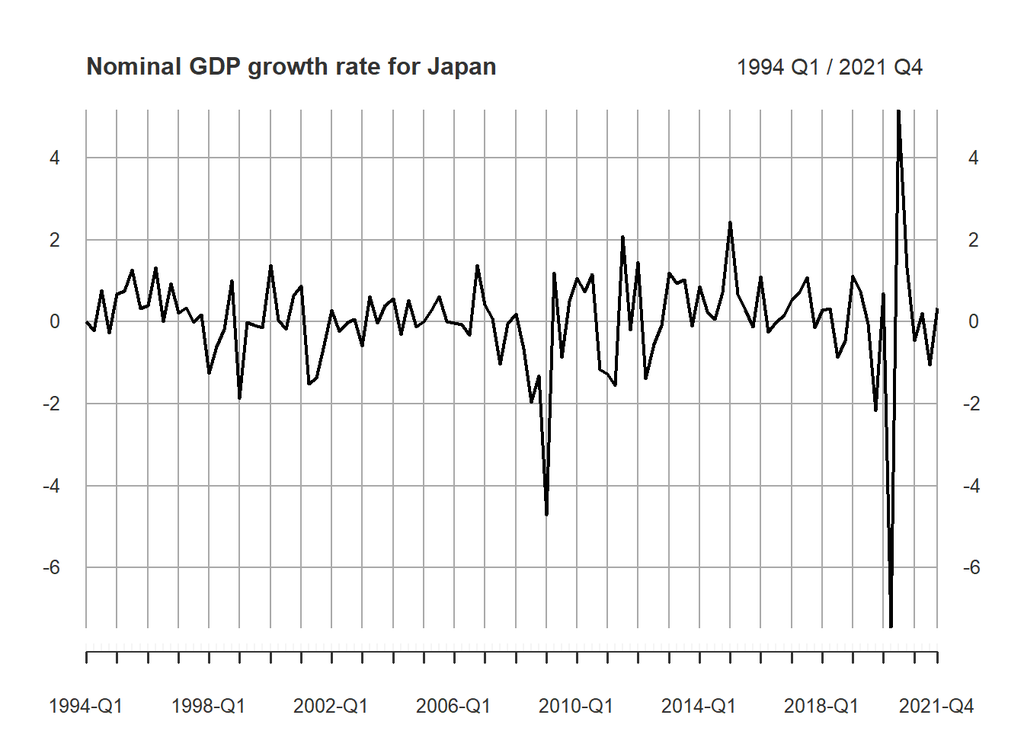

```r
# 時系列プロット
plot(jpnngdp.qr, # 標本
     main = "Nominal GDP growth rate for Japan") # 図題
```

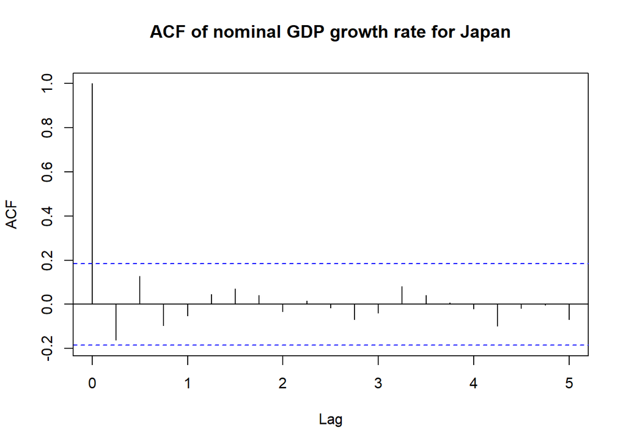

```r
# コレログラム
acf(jpnngdp.qr, # 標本
    main = "ACF of nominal GDP growth rate for Japan") # 図題
```

コレログラムより, 各ラグにおいて自己相関があるとは判断できない.

```r
(T <- length(jpnngdp.qr)) # 標本数
```

```
## [1] 112
```

```r
(m <- round(log(T))) # ラグ m の目安
```

```
## [1] 5
```

これより, ラグ $5$ のかばん検定を行う.

```r
(res <- Box.test(jpnngdp.qr, # 標本
                 lag = m, # ラグ
                 type = "Ljung-Box")) # Ljung and Box (1978)
```

```
##
##  Box-Ljung test
##
## data:  jpnngdp.qr
## X-squared = 6.5193, df = 5, p-value = 0.2589
```

検定統計量の値は $Q(5) = 6.52$, $p$値は $0.259$ である. ラグ $5$, $10$, $15$ に対するかばん検定の結果の表を作成する.

```r
lag <- m * (1:3) # ラグ m, 2m, 3m
res <- sapply(lag, port, x = jpnngdp.qr) # x に対して各 lag の port を計算
res <- t(res) # 転置
# 表を作成
knitr::kable(res, # 計算結果
             digits = c(0, 2, 0, 4), # 少数点以下の最大表示桁数
             col.names = c("$m$", "$Q(m)$", "自由度", "$p$値"), # 列名
             caption = "日本の名目GDP成長率に対するかばん検定", # 表題
             format.args = list(scientific = FALSE)) # 指数表記をしない
```

日本の名目GDP成長率に対するかばん検定

| $m$ | $Q(m)$ | 自由度 | $p$値 |
| --- | --- | --- | --- |
| 5 | 6.52 | 5 | 0.2589 |
| 10 | 7.54 | 10 | 0.6741 |
| 15 | 9.43 | 15 | 0.8539 |

全てにおいて$p$値が $0.05$ より大きいので, 有意水準 $5 \%$ で帰無仮説を棄却できない. つまり, 自己相関があるとは判断できない. よって, GDPは, 原系列は自己相関があると判断できるが, 成長率は自己相関があるとは判断できない.